# Risk Factor Analysis

## Outcome Variable

**Outcome Variable:** y_rate_len

## Predictor Variables

**Intervention Variable:** perdiar24

**Adjustment Set:**

unadjusted

## Stratifying Variables

The analysis was stratified on these variable(s):

- agecat
- studyid
- country

## Data Summary

| agecat | studyid | country | perdiar24 | n_cell | n |
| --- | --- | --- | --- | --- | --- |
| 0-3 months | CMIN | BANGLADESH | 0% | 0 | 43 |
| 0-3 months | CMIN | BANGLADESH | (0%, 5%] | 19 | 43 |
| 0-3 months | CMIN | BANGLADESH | >5% | 24 | 43 |
| 0-3 months | CONTENT | PERU | 0% | 1 | 29 |
| 0-3 months | CONTENT | PERU | (0%, 5%] | 14 | 29 |
| 0-3 months | CONTENT | PERU | >5% | 14 | 29 |
| 0-3 months | EE | PAKISTAN | 0% | 204 | 303 |
| 0-3 months | EE | PAKISTAN | (0%, 5%] | 99 | 303 |
| 0-3 months | EE | PAKISTAN | >5% | 0 | 303 |
| 0-3 months | MAL-ED | BANGLADESH | 0% | 8 | 243 |
| 0-3 months | MAL-ED | BANGLADESH | (0%, 5%] | 143 | 243 |
| 0-3 months | MAL-ED | BANGLADESH | >5% | 92 | 243 |
| 0-3 months | MAL-ED | BRAZIL | 0% | 91 | 168 |
| 0-3 months | MAL-ED | BRAZIL | (0%, 5%] | 75 | 168 |
| 0-3 months | MAL-ED | BRAZIL | >5% | 2 | 168 |
| 0-3 months | MAL-ED | INDIA | 0% | 5 | 183 |
| 0-3 months | MAL-ED | INDIA | (0%, 5%] | 146 | 183 |
| 0-3 months | MAL-ED | INDIA | >5% | 32 | 183 |
| 0-3 months | MAL-ED | NEPAL | 0% | 11 | 156 |
| 0-3 months | MAL-ED | NEPAL | (0%, 5%] | 95 | 156 |
| 0-3 months | MAL-ED | NEPAL | >5% | 50 | 156 |
| 0-3 months | MAL-ED | PERU | 0% | 10 | 265 |
| 0-3 months | MAL-ED | PERU | (0%, 5%] | 107 | 265 |
| 0-3 months | MAL-ED | PERU | >5% | 148 | 265 |
| 0-3 months | MAL-ED | SOUTH AFRICA | 0% | 73 | 211 |
| 0-3 months | MAL-ED | SOUTH AFRICA | (0%, 5%] | 135 | 211 |
| 0-3 months | MAL-ED | SOUTH AFRICA | >5% | 3 | 211 |
| 0-3 months | MAL-ED | TANZANIA, UNITED REPUBLIC OF | 0% | 10 | 228 |
| 0-3 months | MAL-ED | TANZANIA, UNITED REPUBLIC OF | (0%, 5%] | 165 | 228 |
| 0-3 months | MAL-ED | TANZANIA, UNITED REPUBLIC OF | >5% | 53 | 228 |

[output cut: 312 more lines]

The following strata were considered:

- agecat: 0-3 months, studyid: CMIN, country: BANGLADESH
- agecat: 0-3 months, studyid: CONTENT, country: PERU
- agecat: 0-3 months, studyid: EE, country: PAKISTAN
- agecat: 0-3 months, studyid: MAL-ED, country: BANGLADESH
- agecat: 0-3 months, studyid: MAL-ED, country: BRAZIL
- agecat: 0-3 months, studyid: MAL-ED, country: INDIA
- agecat: 0-3 months, studyid: MAL-ED, country: NEPAL
- agecat: 0-3 months, studyid: MAL-ED, country: PERU
- agecat: 0-3 months, studyid: MAL-ED, country: SOUTH AFRICA
- agecat: 0-3 months, studyid: MAL-ED, country: TANZANIA, UNITED REPUBLIC OF
- agecat: 0-3 months, studyid: NIH-Birth, country: BANGLADESH
- agecat: 0-3 months, studyid: NIH-Crypto, country: BANGLADESH
- agecat: 0-3 months, studyid: PROVIDE, country: BANGLADESH
- agecat: 12-15 months, studyid: CMIN, country: BANGLADESH
- agecat: 12-15 months, studyid: CONTENT, country: PERU
- agecat: 12-15 months, studyid: EE, country: PAKISTAN
- agecat: 12-15 months, studyid: Guatemala BSC, country: GUATEMALA
- agecat: 12-15 months, studyid: iLiNS-Zinc, country: BURKINA FASO
- agecat: 12-15 months, studyid: MAL-ED, country: BANGLADESH
- agecat: 12-15 months, studyid: MAL-ED, country: BRAZIL
- agecat: 12-15 months, studyid: MAL-ED, country: INDIA
- agecat: 12-15 months, studyid: MAL-ED, country: NEPAL
- agecat: 12-15 months, studyid: MAL-ED, country: PERU
- agecat: 12-15 months, studyid: MAL-ED, country: SOUTH AFRICA
- agecat: 12-15 months, studyid: MAL-ED, country: TANZANIA, UNITED REPUBLIC OF
- agecat: 12-15 months, studyid: NIH-Birth, country: BANGLADESH
- agecat: 12-15 months, studyid: NIH-Crypto, country: BANGLADESH
- agecat: 12-15 months, studyid: PROVIDE, country: BANGLADESH
- agecat: 12-15 months, studyid: SAS-FoodSuppl, country: INDIA
- agecat: 15-18 months, studyid: CMIN, country: BANGLADESH
- agecat: 15-18 months, studyid: CONTENT, country: PERU
- agecat: 15-18 months, studyid: EE, country: PAKISTAN
- agecat: 15-18 months, studyid: iLiNS-Zinc, country: BURKINA FASO
- agecat: 15-18 months, studyid: MAL-ED, country: BANGLADESH
- agecat: 15-18 months, studyid: MAL-ED, country: BRAZIL
- agecat: 15-18 months, studyid: MAL-ED, country: INDIA
- agecat: 15-18 months, studyid: MAL-ED, country: NEPAL
- agecat: 15-18 months, studyid: MAL-ED, country: PERU
- agecat: 15-18 months, studyid: MAL-ED, country: SOUTH AFRICA
- agecat: 15-18 months, studyid: MAL-ED, country: TANZANIA, UNITED REPUBLIC OF
- agecat: 15-18 months, studyid: NIH-Birth, country: BANGLADESH
- agecat: 15-18 months, studyid: NIH-Crypto, country: BANGLADESH
- agecat: 15-18 months, studyid: PROVIDE, country: BANGLADESH
- agecat: 15-18 months, studyid: SAS-FoodSuppl, country: INDIA
- agecat: 18-21 months, studyid: CMIN, country: BANGLADESH
- agecat: 18-21 months, studyid: CONTENT, country: PERU
- agecat: 18-21 months, studyid: EE, country: PAKISTAN
- agecat: 18-21 months, studyid: MAL-ED, country: BANGLADESH
- agecat: 18-21 months, studyid: MAL-ED, country: BRAZIL
- agecat: 18-21 months, studyid: MAL-ED, country: INDIA
- agecat: 18-21 months, studyid: MAL-ED, country: NEPAL
- agecat: 18-21 months, studyid: MAL-ED, country: PERU
- agecat: 18-21 months, studyid: MAL-ED, country: SOUTH AFRICA
- agecat: 18-21 months, studyid: MAL-ED, country: TANZANIA, UNITED REPUBLIC OF
- agecat: 18-21 months, studyid: NIH-Birth, country: BANGLADESH
- agecat: 18-21 months, studyid: NIH-Crypto, country: BANGLADESH
- agecat: 18-21 months, studyid: PROVIDE, country: BANGLADESH
- agecat: 21-24 months, studyid: CMIN, country: BANGLADESH
- agecat: 21-24 months, studyid: CONTENT, country: PERU
- agecat: 21-24 months, studyid: EE, country: PAKISTAN
- agecat: 21-24 months, studyid: MAL-ED, country: BANGLADESH
- agecat: 21-24 months, studyid: MAL-ED, country: BRAZIL
- agecat: 21-24 months, studyid: MAL-ED, country: INDIA
- agecat: 21-24 months, studyid: MAL-ED, country: NEPAL
- agecat: 21-24 months, studyid: MAL-ED, country: PERU
- agecat: 21-24 months, studyid: MAL-ED, country: SOUTH AFRICA
- agecat: 21-24 months, studyid: MAL-ED, country: TANZANIA, UNITED REPUBLIC OF
- agecat: 21-24 months, studyid: NIH-Birth, country: BANGLADESH
- agecat: 21-24 months, studyid: NIH-Crypto, country: BANGLADESH
- agecat: 21-24 months, studyid: PROVIDE, country: BANGLADESH
- agecat: 3-6 months, studyid: CMIN, country: BANGLADESH
- agecat: 3-6 months, studyid: CONTENT, country: PERU
- agecat: 3-6 months, studyid: EE, country: PAKISTAN
- agecat: 3-6 months, studyid: MAL-ED, country: BANGLADESH
- agecat: 3-6 months, studyid: MAL-ED, country: BRAZIL
- agecat: 3-6 months, studyid: MAL-ED, country: INDIA
- agecat: 3-6 months, studyid: MAL-ED, country: NEPAL
- agecat: 3-6 months, studyid: MAL-ED, country: PERU
- agecat: 3-6 months, studyid: MAL-ED, country: SOUTH AFRICA
- agecat: 3-6 months, studyid: MAL-ED, country: TANZANIA, UNITED REPUBLIC OF
- agecat: 3-6 months, studyid: NIH-Birth, country: BANGLADESH
- agecat: 3-6 months, studyid: NIH-Crypto, country: BANGLADESH
- agecat: 3-6 months, studyid: PROVIDE, country: BANGLADESH
- agecat: 6-9 months, studyid: CMIN, country: BANGLADESH
- agecat: 6-9 months, studyid: CONTENT, country: PERU
- agecat: 6-9 months, studyid: EE, country: PAKISTAN
- agecat: 6-9 months, studyid: Guatemala BSC, country: GUATEMALA
- agecat: 6-9 months, studyid: MAL-ED, country: BANGLADESH
- agecat: 6-9 months, studyid: MAL-ED, country: BRAZIL
- agecat: 6-9 months, studyid: MAL-ED, country: INDIA
- agecat: 6-9 months, studyid: MAL-ED, country: NEPAL
- agecat: 6-9 months, studyid: MAL-ED, country: PERU
- agecat: 6-9 months, studyid: MAL-ED, country: SOUTH AFRICA
- agecat: 6-9 months, studyid: MAL-ED, country: TANZANIA, UNITED REPUBLIC OF
- agecat: 6-9 months, studyid: NIH-Birth, country: BANGLADESH
- agecat: 6-9 months, studyid: NIH-Crypto, country: BANGLADESH
- agecat: 6-9 months, studyid: PROVIDE, country: BANGLADESH
- agecat: 6-9 months, studyid: SAS-FoodSuppl, country: INDIA
- agecat: 9-12 months, studyid: CMIN, country: BANGLADESH
- agecat: 9-12 months, studyid: CONTENT, country: PERU
- agecat: 9-12 months, studyid: EE, country: PAKISTAN
- agecat: 9-12 months, studyid: Guatemala BSC, country: GUATEMALA
- agecat: 9-12 months, studyid: iLiNS-Zinc, country: BURKINA FASO
- agecat: 9-12 months, studyid: MAL-ED, country: BANGLADESH
- agecat: 9-12 months, studyid: MAL-ED, country: BRAZIL
- agecat: 9-12 months, studyid: MAL-ED, country: INDIA
- agecat: 9-12 months, studyid: MAL-ED, country: NEPAL
- agecat: 9-12 months, studyid: MAL-ED, country: PERU
- agecat: 9-12 months, studyid: MAL-ED, country: SOUTH AFRICA
- agecat: 9-12 months, studyid: MAL-ED, country: TANZANIA, UNITED REPUBLIC OF
- agecat: 9-12 months, studyid: NIH-Birth, country: BANGLADESH
- agecat: 9-12 months, studyid: NIH-Crypto, country: BANGLADESH
- agecat: 9-12 months, studyid: PROVIDE, country: BANGLADESH
- agecat: 9-12 months, studyid: SAS-FoodSuppl, country: INDIA

### Dropped Strata

Some strata were dropped due to rare outcomes:

- agecat: 0-3 months, studyid: CMIN, country: BANGLADESH
- agecat: 0-3 months, studyid: CONTENT, country: PERU
- agecat: 0-3 months, studyid: EE, country: PAKISTAN
- agecat: 0-3 months, studyid: MAL-ED, country: BRAZIL
- agecat: 0-3 months, studyid: MAL-ED, country: SOUTH AFRICA
- agecat: 3-6 months, studyid: CMIN, country: BANGLADESH
- agecat: 3-6 months, studyid: EE, country: PAKISTAN
- agecat: 3-6 months, studyid: MAL-ED, country: BRAZIL
- agecat: 3-6 months, studyid: MAL-ED, country: INDIA
- agecat: 3-6 months, studyid: MAL-ED, country: SOUTH AFRICA
- agecat: 6-9 months, studyid: CMIN, country: BANGLADESH
- agecat: 6-9 months, studyid: EE, country: PAKISTAN
- agecat: 6-9 months, studyid: MAL-ED, country: BRAZIL
- agecat: 6-9 months, studyid: MAL-ED, country: INDIA
- agecat: 6-9 months, studyid: MAL-ED, country: PERU
- agecat: 6-9 months, studyid: MAL-ED, country: SOUTH AFRICA
- agecat: 9-12 months, studyid: CMIN, country: BANGLADESH
- agecat: 9-12 months, studyid: EE, country: PAKISTAN
- agecat: 9-12 months, studyid: MAL-ED, country: BRAZIL
- agecat: 9-12 months, studyid: MAL-ED, country: INDIA
- agecat: 9-12 months, studyid: MAL-ED, country: PERU
- agecat: 9-12 months, studyid: MAL-ED, country: SOUTH AFRICA
- agecat: 12-15 months, studyid: CMIN, country: BANGLADESH
- agecat: 12-15 months, studyid: EE, country: PAKISTAN
- agecat: 12-15 months, studyid: Guatemala BSC, country: GUATEMALA
- agecat: 12-15 months, studyid: MAL-ED, country: BRAZIL
- agecat: 12-15 months, studyid: MAL-ED, country: INDIA
- agecat: 12-15 months, studyid: MAL-ED, country: PERU
- agecat: 12-15 months, studyid: MAL-ED, country: SOUTH AFRICA
- agecat: 15-18 months, studyid: CMIN, country: BANGLADESH
- agecat: 15-18 months, studyid: EE, country: PAKISTAN
- agecat: 15-18 months, studyid: MAL-ED, country: BRAZIL
- agecat: 15-18 months, studyid: MAL-ED, country: INDIA
- agecat: 15-18 months, studyid: MAL-ED, country: PERU
- agecat: 15-18 months, studyid: MAL-ED, country: SOUTH AFRICA
- agecat: 18-21 months, studyid: CMIN, country: BANGLADESH
- agecat: 18-21 months, studyid: CONTENT, country: PERU
- agecat: 18-21 months, studyid: EE, country: PAKISTAN
- agecat: 18-21 months, studyid: MAL-ED, country: BRAZIL
- agecat: 18-21 months, studyid: MAL-ED, country: INDIA
- agecat: 18-21 months, studyid: MAL-ED, country: PERU
- agecat: 18-21 months, studyid: MAL-ED, country: SOUTH AFRICA
- agecat: 21-24 months, studyid: CMIN, country: BANGLADESH
- agecat: 21-24 months, studyid: CONTENT, country: PERU
- agecat: 21-24 months, studyid: EE, country: PAKISTAN
- agecat: 21-24 months, studyid: MAL-ED, country: BRAZIL
- agecat: 21-24 months, studyid: MAL-ED, country: INDIA
- agecat: 21-24 months, studyid: MAL-ED, country: PERU
- agecat: 21-24 months, studyid: MAL-ED, country: SOUTH AFRICA

## Methods Detail

We’re interested in the causal parameters $E[Y_a]$ for all values of $a \in \mathcal{A}$. These parameters represent the mean outcome if, possibly contrary to fact, we intervened to set all units to have $A=a$. Under the randomization and positivity assumptions, these are identified by the statistical parameters $\psi_a=E_W[E_{Y|A,W}(Y|A=a,W)]$. In addition, we’re interested in the mean of $Y$, $E[Y]$ under no intervention (the observed mean). We will estimate these parameters by using SuperLearner to fit the relevant likelihood factors – $E_{Y|A,W}(Y|A=a,W)$ and $p(A=a|W)$, and then updating our likelihood fit using a joint TMLE.

For unadjusted analyses ($W=\{\}$), initial likelihoods were estimated using Lrnr_glm to estimate the simple $E(Y|A)$ and Lrnr_mean to estimate $p(A)$. For adjusted analyses, a small library containing Lrnr_glmnet, Lrnr_xgboost, and Lrnr_mean was used.

Having estimated these parameters, we will then use the delta method to estimate relative risks and attributable risks relative to a prespecified baseline level of $A$.

# Results Detail

## Results Plots

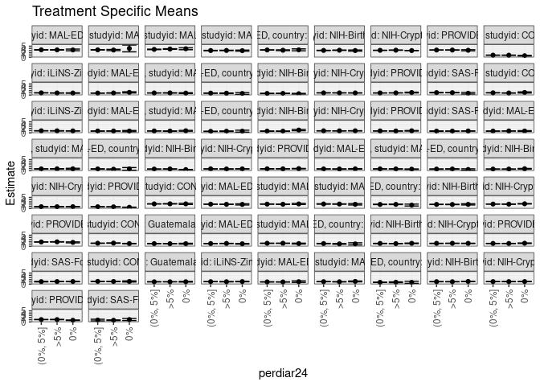

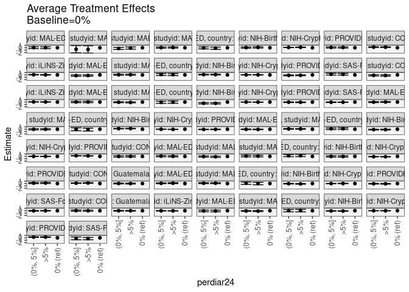

[figure not shown]

## Results Table

### Parameter: TSM

| agecat | studyid | country | intervention_level | baseline_level | estimate | ci_lower | ci_upper |
| --- | --- | --- | --- | --- | --- | --- | --- |
| 0-3 months | MAL-ED | BANGLADESH | 0% | NA | 3.3021986 | 2.9217197 | 3.6826775 |
| 0-3 months | MAL-ED | BANGLADESH | (0%, 5%] | NA | 3.3458080 | 3.2617953 | 3.4298208 |
| 0-3 months | MAL-ED | BANGLADESH | >5% | NA | 3.3319432 | 3.2227784 | 3.4411081 |
| 0-3 months | MAL-ED | INDIA | 0% | NA | 3.9765054 | 2.4394476 | 5.5135632 |
| 0-3 months | MAL-ED | INDIA | (0%, 5%] | NA | 3.3457689 | 3.2534687 | 3.4380691 |
| 0-3 months | MAL-ED | INDIA | >5% | NA | 3.2612624 | 2.9966705 | 3.5258543 |
| 0-3 months | MAL-ED | NEPAL | 0% | NA | 3.8340282 | 3.4067431 | 4.2613133 |
| 0-3 months | MAL-ED | NEPAL | (0%, 5%] | NA | 3.5498816 | 3.4302517 | 3.6695116 |
| 0-3 months | MAL-ED | NEPAL | >5% | NA | 3.7168013 | 3.5765118 | 3.8570908 |
| 0-3 months | MAL-ED | PERU | 0% | NA | 2.9769258 | 2.7383743 | 3.2154772 |
| 0-3 months | MAL-ED | PERU | (0%, 5%] | NA | 3.0280324 | 2.9205196 | 3.1355452 |
| 0-3 months | MAL-ED | PERU | >5% | NA | 3.0743175 | 2.9858355 | 3.1627995 |
| 0-3 months | MAL-ED | TANZANIA, UNITED REPUBLIC OF | 0% | NA | 3.3465881 | 2.9153920 | 3.7777841 |
| 0-3 months | MAL-ED | TANZANIA, UNITED REPUBLIC OF | (0%, 5%] | NA | 3.2935887 | 3.2087240 | 3.3784534 |
| 0-3 months | MAL-ED | TANZANIA, UNITED REPUBLIC OF | >5% | NA | 3.1584488 | 2.9787573 | 3.3381403 |
| 0-3 months | NIH-Birth | BANGLADESH | 0% | NA | 3.0228592 | 2.7701309 | 3.2755875 |
| 0-3 months | NIH-Birth | BANGLADESH | (0%, 5%] | NA | 3.0810976 | 3.0146153 | 3.1475798 |
| 0-3 months | NIH-Birth | BANGLADESH | >5% | NA | 3.1727434 | 3.0785599 | 3.2669270 |
| 0-3 months | NIH-Crypto | BANGLADESH | 0% | NA | 3.0186999 | 2.9550484 | 3.0823515 |
| 0-3 months | NIH-Crypto | BANGLADESH | (0%, 5%] | NA | 3.1332457 | 3.0819961 | 3.1844953 |
| 0-3 months | NIH-Crypto | BANGLADESH | >5% | NA | 3.1961411 | 3.1230717 | 3.2692105 |
| 0-3 months | PROVIDE | BANGLADESH | 0% | NA | 3.1484729 | 2.8948404 | 3.4021053 |
| 0-3 months | PROVIDE | BANGLADESH | (0%, 5%] | NA | 3.2637069 | 3.2196058 | 3.3078080 |
| 0-3 months | PROVIDE | BANGLADESH | >5% | NA | 3.2563014 | 3.1871160 | 3.3254869 |
| 3-6 months | CONTENT | PERU | 0% | NA | 2.0933002 | 1.8015225 | 2.3850780 |
| 3-6 months | CONTENT | PERU | (0%, 5%] | NA | 2.0736534 | 2.0175221 | 2.1297847 |
| 3-6 months | CONTENT | PERU | >5% | NA | 2.1060124 | 2.0120781 | 2.1999467 |
| 3-6 months | MAL-ED | BANGLADESH | 0% | NA | 1.8472373 | 1.5841576 | 2.1103170 |
| 3-6 months | MAL-ED | BANGLADESH | (0%, 5%] | NA | 1.9559532 | 1.8905162 | 2.0213902 |
| 3-6 months | MAL-ED | BANGLADESH | >5% | NA | 1.8890455 | 1.8081193 | 1.9699716 |

[output cut: 165 more lines]

### Parameter: E(Y)

| agecat | studyid | country | intervention_level | baseline_level | estimate | ci_lower | ci_upper |
| --- | --- | --- | --- | --- | --- | --- | --- |
| 0-3 months | MAL-ED | BANGLADESH | NA | NA | 3.3391231 | 3.2734666 | 3.4047796 |
| 0-3 months | MAL-ED | INDIA | NA | NA | 3.3482250 | 3.2503342 | 3.4461159 |
| 0-3 months | MAL-ED | NEPAL | NA | NA | 3.6234175 | 3.5314103 | 3.7154247 |
| 0-3 months | MAL-ED | PERU | NA | NA | 3.0519536 | 2.9854854 | 3.1184219 |
| 0-3 months | MAL-ED | TANZANIA, UNITED REPUBLIC OF | NA | NA | 3.2644991 | 3.1874675 | 3.3415308 |
| 0-3 months | NIH-Birth | BANGLADESH | NA | NA | 3.1100116 | 3.0566021 | 3.1634210 |
| 0-3 months | NIH-Crypto | BANGLADESH | NA | NA | 3.1292449 | 3.0928504 | 3.1656393 |
| 0-3 months | PROVIDE | BANGLADESH | NA | NA | 3.2576810 | 3.2206777 | 3.2946843 |
| 3-6 months | CONTENT | PERU | NA | NA | 2.0841841 | 2.0362519 | 2.1321163 |
| 3-6 months | MAL-ED | BANGLADESH | NA | NA | 1.9276407 | 1.8774065 | 1.9778750 |
| 3-6 months | MAL-ED | NEPAL | NA | NA | 1.9644601 | 1.9083113 | 2.0206088 |
| 3-6 months | MAL-ED | PERU | NA | NA | 2.0156821 | 1.9494666 | 2.0818976 |
| 3-6 months | MAL-ED | TANZANIA, UNITED REPUBLIC OF | NA | NA | 1.8300902 | 1.7622436 | 1.8979368 |
| 3-6 months | NIH-Birth | BANGLADESH | NA | NA | 1.8326915 | 1.7846731 | 1.8807099 |
| 3-6 months | NIH-Crypto | BANGLADESH | NA | NA | 2.0057973 | 1.9693775 | 2.0422170 |
| 3-6 months | PROVIDE | BANGLADESH | NA | NA | 1.9657457 | 1.9318660 | 1.9996254 |
| 6-9 months | CONTENT | PERU | NA | NA | 1.3974236 | 1.3502187 | 1.4446285 |
| 6-9 months | Guatemala BSC | GUATEMALA | NA | NA | 1.1702813 | 1.1261029 | 1.2144597 |
| 6-9 months | MAL-ED | BANGLADESH | NA | NA | 1.2480451 | 1.2083209 | 1.2877694 |
| 6-9 months | MAL-ED | NEPAL | NA | NA | 1.3571408 | 1.3129874 | 1.4012943 |
| 6-9 months | MAL-ED | TANZANIA, UNITED REPUBLIC OF | NA | NA | 1.1907556 | 1.1129385 | 1.2685726 |
| 6-9 months | NIH-Birth | BANGLADESH | NA | NA | 1.2555950 | 1.2150667 | 1.2961234 |
| 6-9 months | NIH-Crypto | BANGLADESH | NA | NA | 1.3282695 | 1.2988292 | 1.3577098 |
| 6-9 months | PROVIDE | BANGLADESH | NA | NA | 1.2824185 | 1.2571827 | 1.3076542 |
| 6-9 months | SAS-FoodSuppl | INDIA | NA | NA | 1.1426155 | 1.1021386 | 1.1830923 |
| 9-12 months | CONTENT | PERU | NA | NA | 1.2048768 | 1.1650186 | 1.2447350 |
| 9-12 months | Guatemala BSC | GUATEMALA | NA | NA | 1.0385134 | 0.9994107 | 1.0776161 |
| 9-12 months | iLiNS-Zinc | BURKINA FASO | NA | NA | 1.0927974 | 1.0590753 | 1.1265195 |
| 9-12 months | MAL-ED | BANGLADESH | NA | NA | 0.9896446 | 0.9509752 | 1.0283140 |
| 9-12 months | MAL-ED | NEPAL | NA | NA | 1.0892372 | 1.0484769 | 1.1299974 |
| 9-12 months | MAL-ED | TANZANIA, UNITED REPUBLIC OF | NA | NA | 0.8131077 | 0.7319679 | 0.8942474 |
| 9-12 months | NIH-Birth | BANGLADESH | NA | NA | 1.0885809 | 1.0534446 | 1.1237171 |
| 9-12 months | NIH-Crypto | BANGLADESH | NA | NA | 1.1234745 | 1.0972274 | 1.1497215 |
| 9-12 months | PROVIDE | BANGLADESH | NA | NA | 1.0499750 | 1.0230130 | 1.0769370 |
| 9-12 months | SAS-FoodSuppl | INDIA | NA | NA | 0.8106649 | 0.6745544 | 0.9467754 |
| 12-15 months | CONTENT | PERU | NA | NA | 0.9291443 | 0.8867697 | 0.9715190 |
| 12-15 months | iLiNS-Zinc | BURKINA FASO | NA | NA | 0.9658283 | 0.9236309 | 1.0080257 |
| 12-15 months | MAL-ED | BANGLADESH | NA | NA | 0.9141004 | 0.8737459 | 0.9544550 |
| 12-15 months | MAL-ED | NEPAL | NA | NA | 0.9514124 | 0.9120195 | 0.9908054 |
| 12-15 months | MAL-ED | TANZANIA, UNITED REPUBLIC OF | NA | NA | 0.8563558 | 0.7920248 | 0.9206869 |
| 12-15 months | NIH-Birth | BANGLADESH | NA | NA | 0.7241623 | 0.6797013 | 0.7686233 |
| 12-15 months | NIH-Crypto | BANGLADESH | NA | NA | 0.9711395 | 0.9465805 | 0.9956985 |
| 12-15 months | PROVIDE | BANGLADESH | NA | NA | 0.9597501 | 0.9335899 | 0.9859102 |
| 12-15 months | SAS-FoodSuppl | INDIA | NA | NA | 1.0267825 | 0.9374856 | 1.1160794 |
| 15-18 months | CONTENT | PERU | NA | NA | 0.9860231 | 0.9406097 | 1.0314365 |
| 15-18 months | iLiNS-Zinc | BURKINA FASO | NA | NA | 0.9228413 | 0.8852625 | 0.9604201 |
| 15-18 months | MAL-ED | BANGLADESH | NA | NA | 0.8241226 | 0.7871907 | 0.8610544 |
| 15-18 months | MAL-ED | NEPAL | NA | NA | 0.8408362 | 0.7994023 | 0.8822700 |
| 15-18 months | MAL-ED | TANZANIA, UNITED REPUBLIC OF | NA | NA | 0.6867479 | 0.6257076 | 0.7477883 |
| 15-18 months | NIH-Birth | BANGLADESH | NA | NA | 0.7727719 | 0.7325606 | 0.8129832 |
| 15-18 months | NIH-Crypto | BANGLADESH | NA | NA | 0.9177168 | 0.8947657 | 0.9406678 |
| 15-18 months | PROVIDE | BANGLADESH | NA | NA | 0.8560998 | 0.8320145 | 0.8801852 |
| 15-18 months | SAS-FoodSuppl | INDIA | NA | NA | 0.7947861 | 0.7590601 | 0.8305122 |
| 18-21 months | MAL-ED | BANGLADESH | NA | NA | 0.8133847 | 0.7790076 | 0.8477619 |
| 18-21 months | MAL-ED | NEPAL | NA | NA | 0.8182798 | 0.7801724 | 0.8563871 |
| 18-21 months | MAL-ED | TANZANIA, UNITED REPUBLIC OF | NA | NA | 0.7437038 | 0.6761886 | 0.8112190 |
| 18-21 months | NIH-Birth | BANGLADESH | NA | NA | 0.7291468 | 0.6930874 | 0.7652062 |
| 18-21 months | NIH-Crypto | BANGLADESH | NA | NA | 0.7977755 | 0.7744353 | 0.8211158 |
| 18-21 months | PROVIDE | BANGLADESH | NA | NA | 0.8393377 | 0.8153485 | 0.8633269 |
| 21-24 months | MAL-ED | BANGLADESH | NA | NA | 0.7694183 | 0.7339448 | 0.8048918 |
| 21-24 months | MAL-ED | NEPAL | NA | NA | 0.7833565 | 0.7426056 | 0.8241074 |
| 21-24 months | MAL-ED | TANZANIA, UNITED REPUBLIC OF | NA | NA | 0.7189328 | 0.6544287 | 0.7834368 |
| 21-24 months | NIH-Birth | BANGLADESH | NA | NA | 0.7172178 | 0.6817161 | 0.7527194 |
| 21-24 months | NIH-Crypto | BANGLADESH | NA | NA | 0.7993353 | 0.7748026 | 0.8238681 |
| 21-24 months | PROVIDE | BANGLADESH | NA | NA | 0.7631391 | 0.7377453 | 0.7885328 |

### Parameter: ATE

| agecat | studyid | country | intervention_level | baseline_level | estimate | ci_lower | ci_upper |
| --- | --- | --- | --- | --- | --- | --- | --- |
| 0-3 months | MAL-ED | BANGLADESH | 0% | 0% | 0.0000000 | 0.0000000 | 0.0000000 |
| 0-3 months | MAL-ED | BANGLADESH | (0%, 5%] | 0% | 0.0436094 | -0.3460344 | 0.4332533 |
| 0-3 months | MAL-ED | BANGLADESH | >5% | 0% | 0.0297447 | -0.3660850 | 0.4255743 |
| 0-3 months | MAL-ED | INDIA | 0% | 0% | 0.0000000 | 0.0000000 | 0.0000000 |
| 0-3 months | MAL-ED | INDIA | (0%, 5%] | 0% | -0.6307366 | -2.1705632 | 0.9090900 |
| 0-3 months | MAL-ED | INDIA | >5% | 0% | -0.7152431 | -2.2749083 | 0.8444221 |
| 0-3 months | MAL-ED | NEPAL | 0% | 0% | 0.0000000 | 0.0000000 | 0.0000000 |
| 0-3 months | MAL-ED | NEPAL | (0%, 5%] | 0% | -0.2841466 | -0.7278626 | 0.1595694 |
| 0-3 months | MAL-ED | NEPAL | >5% | 0% | -0.1172269 | -0.5669531 | 0.3324994 |
| 0-3 months | MAL-ED | PERU | 0% | 0% | 0.0000000 | 0.0000000 | 0.0000000 |
| 0-3 months | MAL-ED | PERU | (0%, 5%] | 0% | 0.0511066 | -0.2105531 | 0.3127663 |
| 0-3 months | MAL-ED | PERU | >5% | 0% | 0.0973917 | -0.1570407 | 0.3518242 |
| 0-3 months | MAL-ED | TANZANIA, UNITED REPUBLIC OF | 0% | 0% | 0.0000000 | 0.0000000 | 0.0000000 |
| 0-3 months | MAL-ED | TANZANIA, UNITED REPUBLIC OF | (0%, 5%] | 0% | -0.0529994 | -0.4924672 | 0.3864685 |
| 0-3 months | MAL-ED | TANZANIA, UNITED REPUBLIC OF | >5% | 0% | -0.1881393 | -0.6552785 | 0.2789999 |
| 0-3 months | NIH-Birth | BANGLADESH | 0% | 0% | 0.0000000 | 0.0000000 | 0.0000000 |
| 0-3 months | NIH-Birth | BANGLADESH | (0%, 5%] | 0% | 0.0582384 | -0.2030880 | 0.3195648 |
| 0-3 months | NIH-Birth | BANGLADESH | >5% | 0% | 0.1498843 | -0.1198232 | 0.4195918 |
| 0-3 months | NIH-Crypto | BANGLADESH | 0% | 0% | 0.0000000 | 0.0000000 | 0.0000000 |
| 0-3 months | NIH-Crypto | BANGLADESH | (0%, 5%] | 0% | 0.1145458 | 0.0328265 | 0.1962650 |
| 0-3 months | NIH-Crypto | BANGLADESH | >5% | 0% | 0.1774412 | 0.0805358 | 0.2743466 |
| 0-3 months | PROVIDE | BANGLADESH | 0% | 0% | 0.0000000 | 0.0000000 | 0.0000000 |
| 0-3 months | PROVIDE | BANGLADESH | (0%, 5%] | 0% | 0.1152341 | -0.1422039 | 0.3726721 |
| 0-3 months | PROVIDE | BANGLADESH | >5% | 0% | 0.1078286 | -0.1550707 | 0.3707279 |
| 3-6 months | CONTENT | PERU | 0% | 0% | 0.0000000 | 0.0000000 | 0.0000000 |
| 3-6 months | CONTENT | PERU | (0%, 5%] | 0% | -0.0196469 | -0.3167748 | 0.2774810 |
| 3-6 months | CONTENT | PERU | >5% | 0% | 0.0127122 | -0.2938134 | 0.3192377 |
| 3-6 months | MAL-ED | BANGLADESH | 0% | 0% | 0.0000000 | 0.0000000 | 0.0000000 |
| 3-6 months | MAL-ED | BANGLADESH | (0%, 5%] | 0% | 0.1087159 | -0.1623799 | 0.3798117 |
| 3-6 months | MAL-ED | BANGLADESH | >5% | 0% | 0.0418082 | -0.2334371 | 0.3170535 |

[output cut: 165 more lines]

### Parameter: PAR

| agecat | studyid | country | intervention_level | baseline_level | estimate | ci_lower | ci_upper |
| --- | --- | --- | --- | --- | --- | --- | --- |
| 0-3 months | MAL-ED | BANGLADESH | 0% | NA | 0.0369245 | -0.3366303 | 0.4104793 |
| 0-3 months | MAL-ED | INDIA | 0% | NA | -0.6282804 | -2.1259548 | 0.8693939 |
| 0-3 months | MAL-ED | NEPAL | 0% | NA | -0.2106107 | -0.6171700 | 0.1959486 |
| 0-3 months | MAL-ED | PERU | 0% | NA | 0.0750279 | -0.1637816 | 0.3138373 |
| 0-3 months | MAL-ED | TANZANIA, UNITED REPUBLIC OF | 0% | NA | -0.0820889 | -0.5010808 | 0.3369030 |
| 0-3 months | NIH-Birth | BANGLADESH | 0% | NA | 0.0871524 | -0.1581617 | 0.3324665 |
| 0-3 months | NIH-Crypto | BANGLADESH | 0% | NA | 0.1105449 | 0.0484252 | 0.1726647 |
| 0-3 months | PROVIDE | BANGLADESH | 0% | NA | 0.1092082 | -0.1387375 | 0.3571538 |
| 3-6 months | CONTENT | PERU | 0% | NA | -0.0091161 | -0.2966190 | 0.2783867 |
| 3-6 months | MAL-ED | BANGLADESH | 0% | NA | 0.0804035 | -0.1806311 | 0.3414380 |
| 3-6 months | MAL-ED | NEPAL | 0% | NA | -0.0954796 | -0.3390950 | 0.1481357 |
| 3-6 months | MAL-ED | PERU | 0% | NA | 0.1152898 | -0.1980254 | 0.4286050 |
| 3-6 months | MAL-ED | TANZANIA, UNITED REPUBLIC OF | 0% | NA | 0.2868766 | -0.1284995 | 0.7022528 |
| 3-6 months | NIH-Birth | BANGLADESH | 0% | NA | -0.0339056 | -0.3060648 | 0.2382537 |
| 3-6 months | NIH-Crypto | BANGLADESH | 0% | NA | -0.1076635 | -0.1856219 | -0.0297050 |
| 3-6 months | PROVIDE | BANGLADESH | 0% | NA | 0.1973150 | -0.0120266 | 0.4066566 |
| 6-9 months | CONTENT | PERU | 0% | NA | 0.1804985 | 0.0767461 | 0.2842509 |
| 6-9 months | Guatemala BSC | GUATEMALA | 0% | NA | -0.0041621 | -0.1827780 | 0.1744537 |
| 6-9 months | MAL-ED | BANGLADESH | 0% | NA | 0.1175331 | -0.0515149 | 0.2865810 |
| 6-9 months | MAL-ED | NEPAL | 0% | NA | 0.1355645 | -0.0411004 | 0.3122293 |
| 6-9 months | MAL-ED | TANZANIA, UNITED REPUBLIC OF | 0% | NA | 0.0995197 | -0.3804288 | 0.5794681 |
| 6-9 months | NIH-Birth | BANGLADESH | 0% | NA | -0.0850118 | -0.2200138 | 0.0499902 |
| 6-9 months | NIH-Crypto | BANGLADESH | 0% | NA | 0.0029416 | -0.0552941 | 0.0611773 |
| 6-9 months | PROVIDE | BANGLADESH | 0% | NA | -0.0939558 | -0.2253454 | 0.0374339 |
| 6-9 months | SAS-FoodSuppl | INDIA | 0% | NA | -0.0188602 | -0.1069108 | 0.0691904 |
| 9-12 months | CONTENT | PERU | 0% | NA | 0.0140513 | -0.2260767 | 0.2541794 |
| 9-12 months | Guatemala BSC | GUATEMALA | 0% | NA | -0.0324126 | -0.1751232 | 0.1102979 |
| 9-12 months | iLiNS-Zinc | BURKINA FASO | 0% | NA | -0.0491258 | -0.1357033 | 0.0374517 |
| 9-12 months | MAL-ED | BANGLADESH | 0% | NA | -0.0987290 | -0.4358726 | 0.2384147 |
| 9-12 months | MAL-ED | NEPAL | 0% | NA | -0.1208063 | -0.3045780 | 0.0629654 |
| 9-12 months | MAL-ED | TANZANIA, UNITED REPUBLIC OF | 0% | NA | 0.0000091 | -0.4809269 | 0.4809451 |
| 9-12 months | NIH-Birth | BANGLADESH | 0% | NA | -0.1116123 | -0.2113638 | -0.0118609 |
| 9-12 months | NIH-Crypto | BANGLADESH | 0% | NA | -0.0224187 | -0.0764059 | 0.0315685 |
| 9-12 months | PROVIDE | BANGLADESH | 0% | NA | 0.3029199 | 0.1996547 | 0.4061851 |
| 9-12 months | SAS-FoodSuppl | INDIA | 0% | NA | -0.2540567 | -0.6492800 | 0.1411667 |
| 12-15 months | CONTENT | PERU | 0% | NA | 0.2462390 | 0.0938362 | 0.3986418 |
| 12-15 months | iLiNS-Zinc | BURKINA FASO | 0% | NA | 0.0508291 | -0.0350494 | 0.1367076 |
| 12-15 months | MAL-ED | BANGLADESH | 0% | NA | -0.2891186 | -0.5575319 | -0.0207054 |
| 12-15 months | MAL-ED | NEPAL | 0% | NA | 0.0715265 | -0.1196932 | 0.2627462 |
| 12-15 months | MAL-ED | TANZANIA, UNITED REPUBLIC OF | 0% | NA | 0.1456319 | -0.2660804 | 0.5573442 |
| 12-15 months | NIH-Birth | BANGLADESH | 0% | NA | 0.1224897 | -0.0268358 | 0.2718152 |
| 12-15 months | NIH-Crypto | BANGLADESH | 0% | NA | 0.0153421 | -0.0336531 | 0.0643374 |
| 12-15 months | PROVIDE | BANGLADESH | 0% | NA | -0.1729744 | -0.3525601 | 0.0066113 |
| 12-15 months | SAS-FoodSuppl | INDIA | 0% | NA | 0.2176603 | -0.0944498 | 0.5297703 |
| 15-18 months | CONTENT | PERU | 0% | NA | -0.1870040 | -0.4503770 | 0.0763691 |
| 15-18 months | iLiNS-Zinc | BURKINA FASO | 0% | NA | 0.0484591 | -0.0223316 | 0.1192499 |
| 15-18 months | MAL-ED | BANGLADESH | 0% | NA | 0.0270985 | -0.2379674 | 0.2921645 |
| 15-18 months | MAL-ED | NEPAL | 0% | NA | -0.0991674 | -0.2829719 | 0.0846370 |
| 15-18 months | MAL-ED | TANZANIA, UNITED REPUBLIC OF | 0% | NA | -0.0748518 | -0.5126196 | 0.3629160 |
| 15-18 months | NIH-Birth | BANGLADESH | 0% | NA | -0.4858222 | -0.7689518 | -0.2026925 |
| 15-18 months | NIH-Crypto | BANGLADESH | 0% | NA | -0.0073978 | -0.0518757 | 0.0370800 |
| 15-18 months | PROVIDE | BANGLADESH | 0% | NA | -0.0676554 | -0.2010284 | 0.0657177 |
| 15-18 months | SAS-FoodSuppl | INDIA | 0% | NA | -0.0483944 | -0.1103575 | 0.0135687 |
| 18-21 months | MAL-ED | BANGLADESH | 0% | NA | -0.0070236 | -0.1903920 | 0.1763448 |
| 18-21 months | MAL-ED | NEPAL | 0% | NA | -0.0247855 | -0.2534871 | 0.2039162 |
| 18-21 months | MAL-ED | TANZANIA, UNITED REPUBLIC OF | 0% | NA | -0.0615898 | -0.6499036 | 0.5267241 |
| 18-21 months | NIH-Birth | BANGLADESH | 0% | NA | 0.2492178 | 0.1645772 | 0.3338584 |
| 18-21 months | NIH-Crypto | BANGLADESH | 0% | NA | -0.0166314 | -0.0601682 | 0.0269054 |
| 18-21 months | PROVIDE | BANGLADESH | 0% | NA | -0.0760381 | -0.1724972 | 0.0204211 |
| 21-24 months | MAL-ED | BANGLADESH | 0% | NA | -0.0508806 | -0.1804032 | 0.0786420 |
| 21-24 months | MAL-ED | NEPAL | 0% | NA | 0.1163805 | -0.0042416 | 0.2370026 |
| 21-24 months | MAL-ED | TANZANIA, UNITED REPUBLIC OF | 0% | NA | 0.1872471 | -0.1189333 | 0.4934274 |
| 21-24 months | NIH-Birth | BANGLADESH | 0% | NA | -0.1528330 | -0.2991821 | -0.0064838 |
| 21-24 months | NIH-Crypto | BANGLADESH | 0% | NA | -0.0099200 | -0.0514495 | 0.0316094 |
| 21-24 months | PROVIDE | BANGLADESH | 0% | NA | 0.2234908 | 0.1641755 | 0.2828061 |